# Bases de données

25 mai 2017

## Buts et approche

## Buts de la présentation

### **Démystifier les bases de données biologiques:**

- Définition des bases de données biologies
- Les types de bases de données
- Laquelle choisir?

### **Présenter les ressources disponibles sur R/Bioconductor**

### **Répondre à vos questions**

## Les bases de données biologiques

## Les bases de données

### Définition (adaptée de Wikipedia)

Une base de données est un outil qui permet de **stocker** et de **retrouver** de l'information.

## Les bases de données biologiques

### Définition (adaptée de Wikipedia)

Une base de données est un outil qui permet de **stocker** et de **retrouver** de l'information **biologique**.

- Génome de référence
- Données expérimentales
- Articles scientifiques
- Annotations
- Etc…

## Structure des bases de données

### Simple

| chrom | chromStart | chromEnd | name | score | strand |
| --- | --- | --- | --- | --- | --- |
| chr1 | 839741 | 840250 | chr1:839741-840250 | 24 | . |
| chr1 | 840753 | 841210 | chr1:840753-841210 | 32 | . |
| chr1 | 845485 | 845678 | chr1:845485-845678 | 2 | . |
| chr1 | 855764 | 856157 | chr1:855764-856157 | 2 | . |
| chr1 | 856539 | 856757 | chr1:856539-856757 | 2 | . |

5 premières lignes et 6 premières colonnes du fichier human_permissive_enhancers_phase_1_and_2.bed.gz téléchargé sur le site de Fantom5 (http://fantom.gsc.riken.jp/5/datafiles/latest/extra/Enhancers/)

## Structure des bases de données

### Complexe

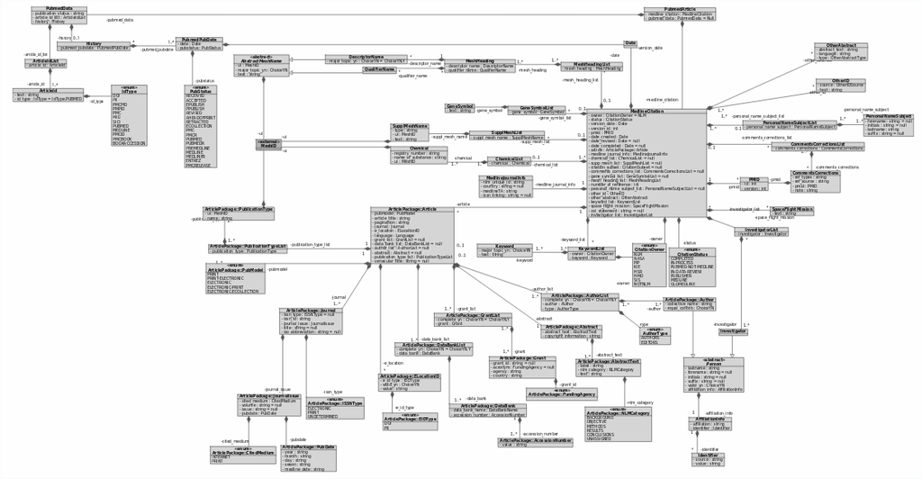

Figure produite par Régis Ongaro.

## Progression des BD biologiques (1)

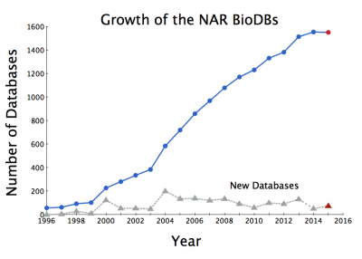

http://scienceblogs.com/digitalbio/files/2015/01/number-of-dbs-2015-400x286.png

## Progression des BD biologiques (2)

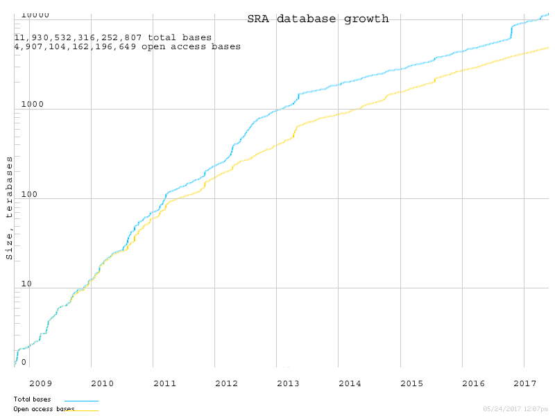

https://www.ncbi.nlm.nih.gov/Traces/sra/i/g.png

## Les limites des bases de données

### **Erreurs** d'annotation et de séquençage.

### Information **redondantes**

### **Biais** envers certaines espèces

[figure not shown]

## Types de base de données

- Primaires
- Secondaires
- Spécialisés

## Bases de données primaires

[figure not shown]

http://www.ddbj.nig.ac.jp/wp-content/uploads/insdc_shoukai550_20130515.png

## Bases de données secondaires

- L'information brute des bases de données primaires est transformée:
  - Outils bioinformatiques
  - Vérification par des experts
  - Croisements entre plusieurs bases de données

## Prédiction de gène et annotations (1)

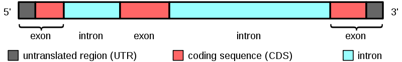

- Définir la structure du gène (exon, intron, UTR, etc…)
- Définir les isoformes des gènes
- Obtenir la position des gènes sur le génome

Image: https://en.wikipedia.org/wiki/File:Gene_structure.svg

## NCBI - Refseq

[figure not shown]

## Pipeline - Refseq

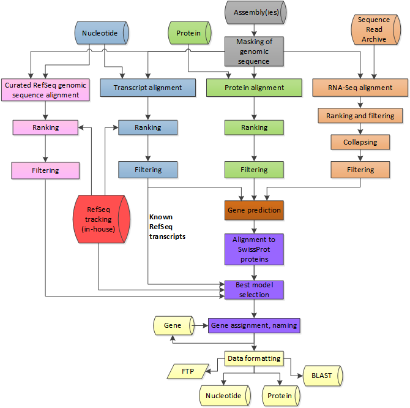

https://www.ncbi.nlm.nih.gov/genome/annotation_euk/process/

## Ensembl

[figure not shown]

## Pipeline - Ensembl

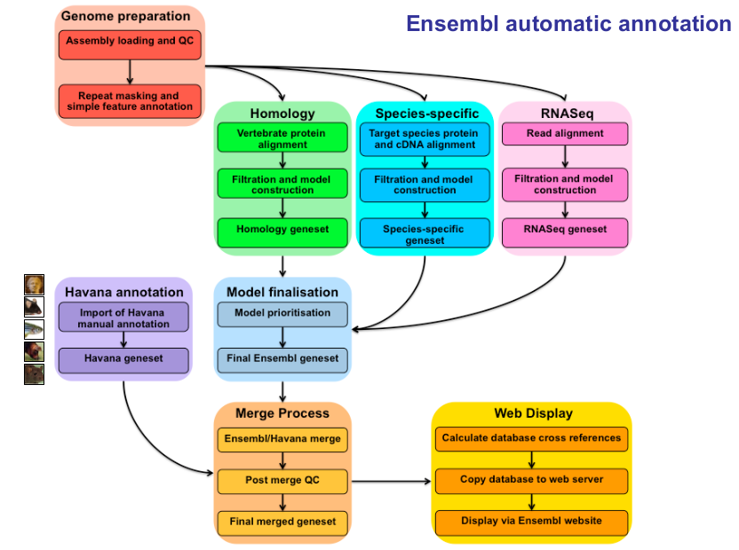

https://www.slideshare.net/DeniseRCarvalhoSilva/ensembl-online-webinar-series-genes-and-transcripts

## Accéder à l'information des BD (1)

- Portail du NCBI

[figure not shown]

- Portail d'ensembl

[figure not shown]

## Accéder à l'information des BD (2)

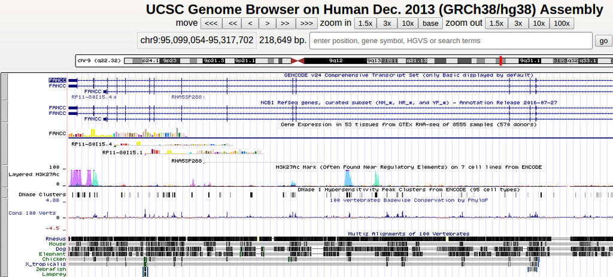

## Accéder à l'information des BD (3)

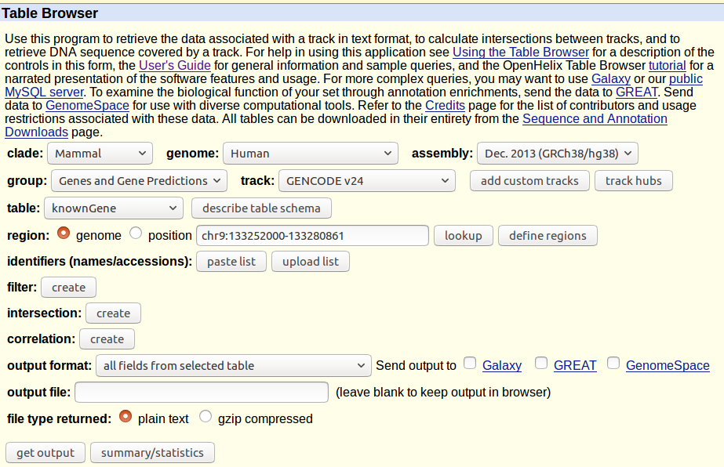

https://genome.ucsc.edu/cgi-bin/hgTables

## Bioconductor

## Présentation de R

- Le langage R se situe dans la catégorie des langages interprétés
- Les programmes en R ne sont donc pas compilés
- Le langage R se spécialise pour les analyses statistiques et la visualisation de données

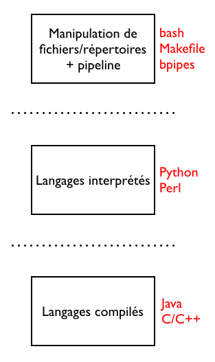

## Les paquets CRAN

- Un des points forts de R est la gestion généralement simple des paquets
- Ils regroupent des fonctions ayant un thème commun:
  - La création de certains types de graphiques
  - Analyses statistiques
  - …
- Gestion automatisée des dépendances

## Présentation de Bioconductor

- Dépôt (repository) de paquets R en lien avec la bioinformatique:
  - Génomique
  - Protéomique
  - Metabolomique
  - Etc…
- Plus de 2000 paquets disponibles
- Processus en place pour s’assurer que tous les paquets sont fonctionnels, soient documentés et puissent être installés facilement

[figure not shown]

## Types de paquets

- Outil (*software*):
  - Paquets pour l’analyse des données.
- Annotation (*AnnotationData*):
  - Séquences d’organismes
  - Annotations de génome / biopuces
- Expérience (*ExperimentData*):
  - Données d’expérience, en format directement utilisable par R.

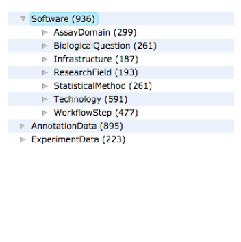

## Annotations

| Type.de.paquet | Exemple | Description |
| --- | --- | --- |
| BSgenome | BSgenome.Hsapiens.UCSC.hg19 | Séquences de référence |
| org | org.Hs.eg.db | Identifiants de diverses bases de données (RefSeq, Ensembl, Uniprot, etc…) |
| TxDb | TxDb.Hsapiens.UCSC.hg19.knownGene | Description des exons, gènes et transcrits |

## Avantages

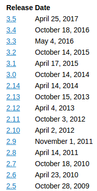

- Cycle d'environ 6 mois
- Stabilité
- Reproductibilité

## En savoir plus:

- [Cours de Kasper Hansen](https://www.youtube.com/playlist?list=PLA0uMgYDbgCKNH8Cm-68gEnw39fR5mhFa)
- Coursera
- BIF-4004/BIF-7004: Génomique computationnelle

## Questions

## Questions (1)

### Comment évaluer la qualité de notre base de données

1. Source
2. Fréquence des mises à jour
3. Validation par des experts
4. Exploration des données

## Questions (2)

### Conversion du format d'une BD: large <-> long

| Gène | Échantillon_1 | Échantillon_2 | Échantillon_3 |
| --- | --- | --- | --- |
| X | 1 | 2 | 0 |
| Y | 0 | 3 | 0 |
| Z | 0 | 0 | 1 |

## Questions (2)

### Conversion du format d'une BD: large <-> long

[output not shown]

## Questions (2)

### Conversion du format d'une BD: large <-> long

```r
library(tidyverse)
large <- read_csv("_data/wide.csv")
large
```

```
## # A tibble: 3 × 4
##    Gène Échantillon_1 Échantillon_2 Échantillon_3
##   <chr>         <int>         <int>         <int>
## 1     X             1             2             0
## 2     Y             0             3             0
## 3     Z             0             0             1
```

## Questions (2)

### Conversion du format d'une BD: large <-> long

```r
long <- gather(large, Échantillon, Valeur, -Gène)
long
```

```
## # A tibble: 9 × 3
##    Gène   Échantillon Valeur
##   <chr>         <chr>  <int>
## 1     X Échantillon_1      1
## 2     Y Échantillon_1      0
## 3     Z Échantillon_1      0
## 4     X Échantillon_2      2
## 5     Y Échantillon_2      3
## 6     Z Échantillon_2      0
## 7     X Échantillon_3      0
## 8     Y Échantillon_3      0
## 9     Z Échantillon_3      1
```

## Questions (2)

### Conversion du format d'une BD: large <-> long

```r
spread(long, Échantillon, Valeur)
```

```
## # A tibble: 3 × 4
##    Gène Échantillon_1 Échantillon_2 Échantillon_3
## * <chr>         <int>         <int>         <int>
## 1     X             1             2             0
## 2     Y             0             3             0
## 3     Z             0             0             1
```

## Autres questions?

[figure not shown]

https://github.com/CharlesJB/JR_Workshop_BD